# VIBRANT clinical data augmentation

Author

Laura Vermeren, Laura Symul, Lara Wautier, Céline Bugli

Published

July 2, 2026

The purpose of this document is to create

- a `participants` table with study-level participant-invariant information (*e.g.*, arm, site, etc.), including the population flags along with a
  - `participants_variable_dictionary`, a table describing the variables contained in the `participants` table
- a `visits_long` table with the `visit_code` and `study_day` for each participant and each CRFs. This table is used to identify residual discrepancies between CRFs in `visit_code` and `study_day` (and harmonize them if needed).
- a `visits` table with one row per `pid` and `visit_code` and the following columns
  - `study_day` harmonized `study_day` across CRFs
  - `visit_type`: whether it is a `clinic` or `home` visit
  - `visit_planned`: whether the visit was `planned` or `additional`
  - `visit_attended`: whether the visit was attended or not. For `home` visits, this notes whether we have any CRF data for that visit
  - `specimen_collection_swab` (`collected`, `not collected`, `unclear`) [CRF35]
  - `specimen_collection_softcup` (`collected`, `not collected`, `unclear`) [CRF35]
  - `specimen_collection_cytobrush` (`collected`, `not collected`, `unclear`) [CRF35]
  - `specimen_collection_home_swab` (`collected`, `not collected`, `unclear`) [CRF47]

  along with a
  - `visits_variable_dictionary`

We will first create the `participants` table with `pid`, `site`, `location`, `randomized` and `arm`, then we will build the visits table because we need the correspondance between `visit_code` and `study_day` for some of the criteria to build the population flags (`ITT`, `mITT` and `PP`).

# Loading the CRF data processed in the previous step (`01a clinical CRF data cleaning.qmd`)

```r
data_dir <- get_01_output_dir()

crf_clean_file <- data_dir |>
  fs::dir_ls() |>
  str_subset("01_crf_clean") |>
  sort(decreasing = TRUE) |>
  magrittr::extract(1)
load(crf_clean_file, verbose = TRUE)
```

```
Loading objects:
  crf_clean
```

```r
crf_clean |> names()
```

```
 [1] "crf1"          "crf101"        "crf2"          "crf102"
 [5] "crf3"          "crf4"          "crf5"          "crf6"
 [9] "crf7"          "crf8"          "crf9"          "crf10"
[13] "crf11"         "crf12"         "crf13"         "crf14"
[17] "crf15"         "crf16"         "crf17"         "crf18"
[21] "crf19"         "crf20"         "crf21"         "crf22"
[25] "crf23"         "crf24"         "crf25"         "crf26"
[29] "crf27"         "crf27_long"    "crf28"         "crf29"
[33] "crf29_summary" "crf30"         "crf31"         "crf32"
[37] "crf33"         "crf34"         "crf35"         "crf40"
[41] "crf41"         "crf42"         "crf43"         "crf44"
[45] "crf45"         "crf46"         "crf47"         "crf47_long"
```

```r
rm(crf_clean_file)

exposure_file <- data_dir |>
  fs::dir_ls() |>
  str_subset("01_exposures") |>
  sort(decreasing = TRUE) |>
  magrittr::extract(1)
load(exposure_file, verbose = TRUE)
```

```
Loading objects:
  exposures
```

```r
rm(exposure_file)
```

# `participants` table

The `participants` table will contain one row per `pid` for all `pids` identified throughout all CRFs and the following columns:

- `pid`: participant ID
- `site` (`MGH` or `CAP`)
- `location`: location of the participant (`US` or `SA`)
- `randomized`: whether the participant was randomized
- `arm`: the participant’s arm
  - one of `NA` if not randomized,
  - `Blinded` when still blinded,
  - `Pl` if randomized to the Placebo
  - `LC106-7` if randomized to 7 days of LC106 after metronidazole
  - `LC106-3` if randomized to 3 days of LC106 after metronidazole
  - `LC106-o` if randomized to 7 days of LC106 *overlaping* with metronidazole
  - `LC115` if randomized to 7 days of LC115 after metronidazole
- `ITT` intention-to-treat population flag (`TRUE` or `FALSE`)
- `mITT` modified intention-to-treat population flag (`TRUE` or `FALSE`)
- `PP` per-protocol population flag (`TRUE` or `FALSE`)

## All `pid`s

```r
participants <-
  map(
    crf_clean,
    function(x) {
      x |> filter(!is.na(pid)) |> select(pid) |> distinct() |> mutate(pid = pid |> as.character())
    }
  ) |>
  bind_rows() |>
  distinct()
```

## Study site

```r
participants <-
  participants |>
  mutate(
    site = case_when(
      str_detect(pid, "^06810") | str_detect(pid, "^10") ~ "MGH",
      str_detect(pid, "^06820") | str_detect(pid, "^20") ~ "CAP",
      TRUE ~ NA_character_
    ),
    location = ifelse(site == "MGH", "US", "SA")
  )
```

## Randomization (`randomized` and `arm`)

Randomization data is available in CRF13.

**Important**

This code, along with all assay QCs, was written and executed **before** arm unblinding, which happened on June 17th, 2025. Consequently, here, we only have data related to *whether* a participant was randomized (`randomized`), and if so, whether they were in the only open (unblinded) arm (`group4`, arm LC-106-o in which participants received the LBP before finishing their course of metronidazole), and what their randomization code (`treatment_code`) was, but we do not yet know the actual arm of the participant (`arm`). We still define a placeholder `arm` column that will be updated after unblinding.

Unblinding itself is done in the script `92-unblinding.qmd`, after all data QC has been performed and that a `MultiAssayExperiment` object has been created.

We look at CRF13 to identify randomized participants: randomized participants are participants with a `treatment_code`.

```r
all(crf_clean$crf13$dfseq == 1000)
!any(is.na(crf_clean$crf13$treatment_code))
!any(duplicated(crf_clean$crf13$pid))
```

[output not shown]

```r
participants <-
  participants |>
  select(-any_of(c("randomized", "group4", "arm"))) |>
  left_join(
    crf_clean$crf13 |>
      select(pid, group4) |>
      mutate(randomized = TRUE, pid = pid |> as.character()),
    by = join_by(pid)
  ) |>
  mutate(
    randomized = randomized |> replace_na(FALSE)
  )
```

```r
# For now, we do not know the arms yet, only whether participants were in the overlap arm or not.

participants <-
  participants |>
  mutate(
    arm = case_when(
      group4 == "Yes" ~ "LC106-o",
      group4 == "No" ~ "Blinded",
      is.na(group4) ~ NA_character_
    ) |>
      factor(
        levels = c("Pl", "LC106-7", "LC106-3", "LC106-o", "LC115", "Blinded")
      )
  ) |>
  select(-group4)
```

```r
participants |>
  dplyr::count(site, randomized, arm) |>
  gt(caption = "Number of randomized participants per site and per arm")
```

Number of randomized participants per site and per arm

| site | randomized | arm | n |
| --- | --- | --- | --- |
| CAP | FALSE | NA | 393 |
| CAP | TRUE | LC106-o | 15 |
| CAP | TRUE | Blinded | 57 |
| MGH | FALSE | NA | 43 |
| MGH | TRUE | LC106-o | 1 |
| MGH | TRUE | Blinded | 23 |

# Visit tables (`visits_long` and `visits`)

## `visits_long`

We build the `visits_long` table by concatenating the `pid`, `visit_code`, and `study_day` from all CRFs. It consequently has the following columns

- `pid`
- `visit_code`
- `study_day`
- `crf_plate`

```r
visit_crfs <- crf_clean |> names() |> unique()
# we remove CRF 29, (and 29_bis below) (AE), 31 (CM), and 34 (Protocol deviation)
visit_crfs <- visit_crfs |>
  setdiff(str_c("crf", c("27_long", "29", "29_summary", "31", "34", "47_long")))

visits_long <-
  map(
    visit_crfs,
    ~ crf_clean[[.x]] |>
      select(pid, any_of(c("visit_code", "study_day"))) |>
      mutate(crf_plate = .x |> str_remove("crf"))
  ) |>
  bind_rows() |>
  filter(crf_plate != "29_bis") |>
  mutate(
    pid = pid |> as.character(),
    crf_plate = crf_plate |> fct_inorder()
  )
```

Overview of visits’s `study_day` by CRF plates.

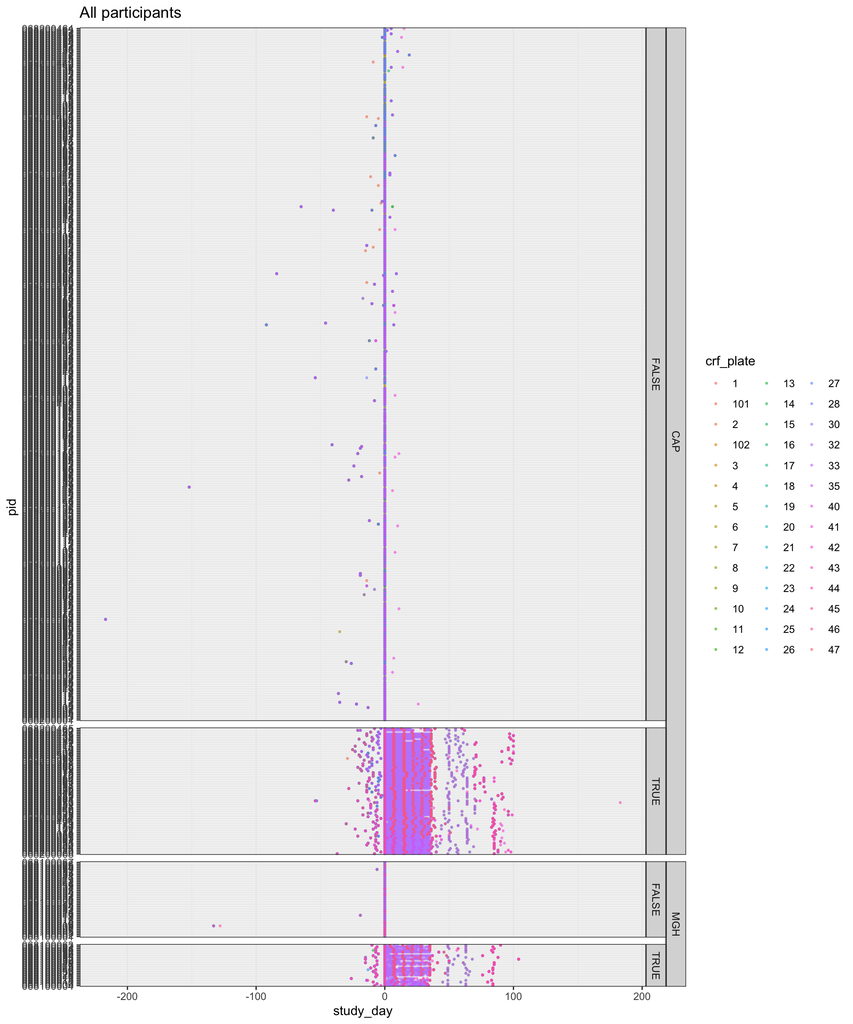

```r
visits_long |>
  left_join(participants, by = join_by(pid)) |>
  ggplot() +
  aes(x = study_day, y = pid, col = crf_plate) +
  geom_point(size = 0.5, alpha = 0.5) +
  ggh4x::facet_nested(vars(site, randomized), scales = "free_y", space = "free_y") +
  ggtitle("All participants")
```

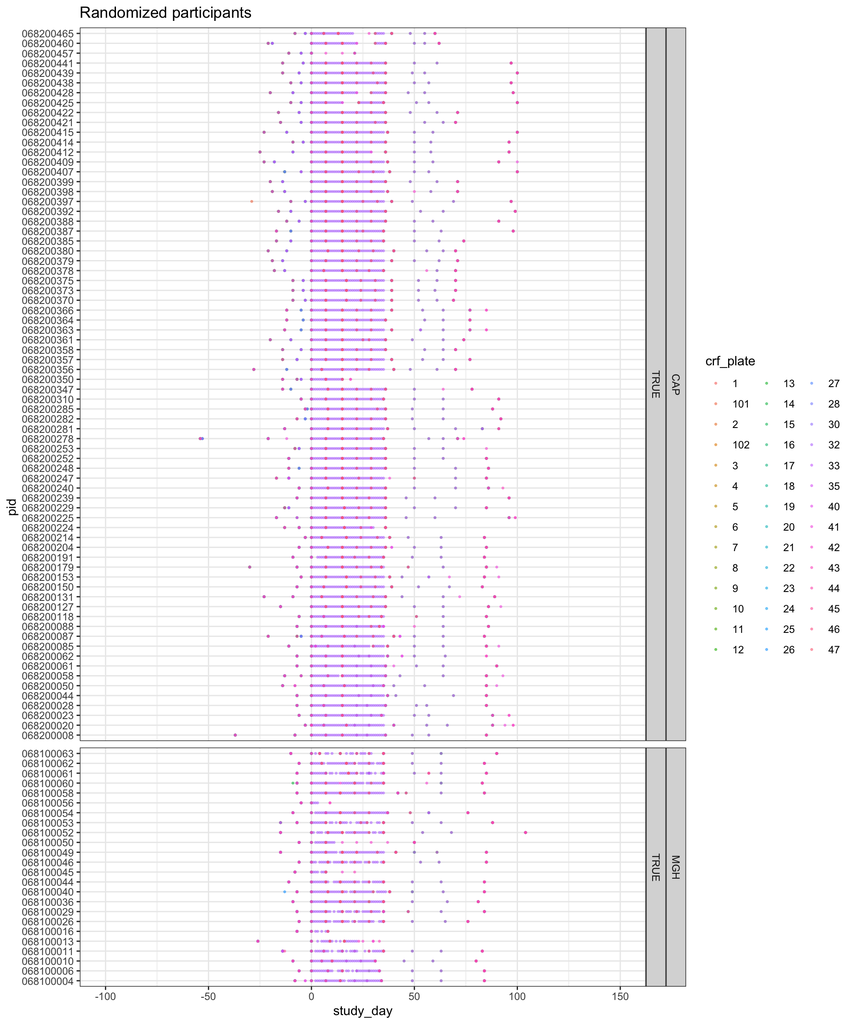

```r
g_randomized <-
  visits_long |>
  left_join(participants, by = join_by(pid)) |>
  filter(randomized) |>
  ggplot() +
  aes(x = study_day, y = pid, col = crf_plate) +
  geom_point(size = 0.5, alpha = 0.5) +
  facet_grid(site + randomized ~ ., scales = "free_y", space = "free_y") +
  ggtitle("Randomized participants")

g_randomized + scale_x_continuous(limits = c(-100, 150))
```

And by visit code.

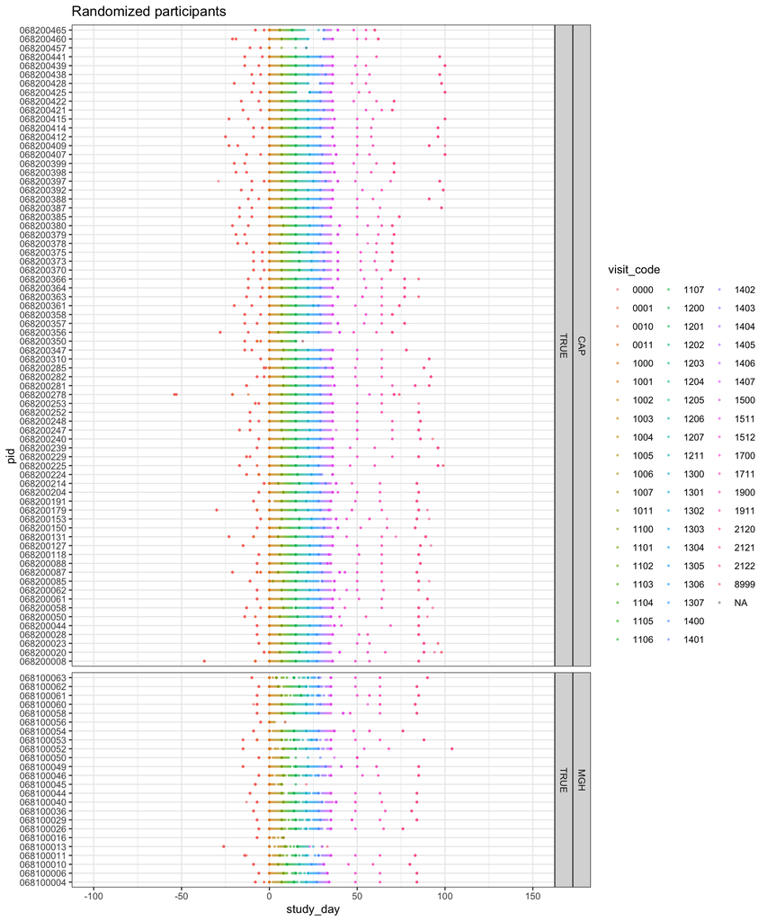

```r
g_randomized <-
  visits_long |>
  left_join(participants, by = join_by(pid)) |>
  filter(randomized) |>
  ggplot() +
  aes(x = study_day, y = pid, col = visit_code) +
  geom_point(size = 0.5, alpha = 0.5) +
  facet_grid(site + randomized ~ ., scales = "free_y", space = "free_y") +
  # scale_x_continuous(limits = c(-100, 150)) +
  ggtitle("Randomized participants")

g_randomized + scale_x_continuous(limits = c(-100, 150))
```

Overview of `visit_code`

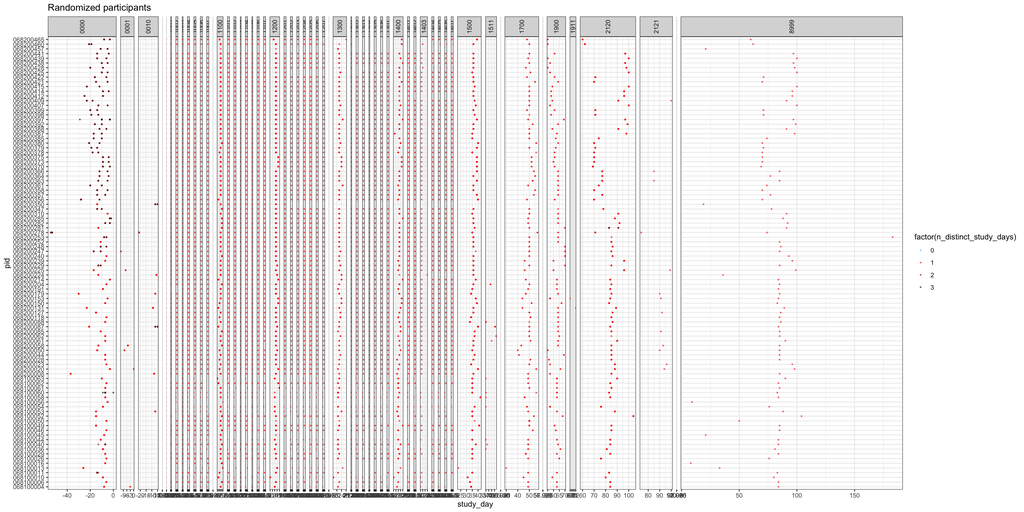

```r
g_randomized <-
  visits_long |>
  filter(!is.na(visit_code)) |>
  arrange(pid, visit_code) |>
  group_by(pid, visit_code) |>
  mutate(n_distinct_study_days = study_day |> na.omit() |> n_distinct()) |>
  ungroup() |>
  left_join(participants, by = join_by(pid)) |>
  filter(randomized) |>
  ggplot() +
  aes(x = study_day, y = pid, col = n_distinct_study_days |> factor()) +
  geom_point(size = 0.5, alpha = 0.5) +
  facet_grid(~visit_code, scales = "free", space = "free") +
  scale_color_manual(values = c("steelblue1", colorRampPalette(c("red", "black"))(3))) +
  # scale_x_continuous(limits = c(-100, 150)) +
  ggtitle("Randomized participants") +
  theme(strip.text.x = element_text(angle = 90))

g_randomized
```

```r
mismatched_study_days <-
  visits_long |>
  filter(!is.na(visit_code)) |>
  arrange(pid, visit_code) |>
  group_by(pid, visit_code) |>
  mutate(n_distinct_study_days = study_day |> na.omit() |> n_distinct()) |>
  ungroup() |>
  filter(n_distinct_study_days > 1) |>
  filter(!is.na(study_day)) |>
  group_by(pid, visit_code) |>
  mutate(
    most_freq_study_day = study_day |>
      factor() |>
      fct_infreq() |>
      levels() |>
      magrittr::extract(1) |>
      as.numeric(),
    diff_with_most_freq_study_day = (study_day - most_freq_study_day),
    n_same = sum(study_day == most_freq_study_day),
    n_diff = sum(study_day != most_freq_study_day),
    n = n(),
    f_diff = n_diff / n
  ) |>
  ungroup()

mismatched_study_days |>
  filter(visit_code >= 1000) |>
  gt()
```

| pid | visit_code | study_day | crf_plate | n_distinct_study_days | most_freq_study_day | diff_with_most_freq_study_day | n_same | n_diff | n | f_diff |
| --- | --- | --- | --- | --- | --- | --- | --- | --- | --- | --- |
| 068200281 | 2120 | 83 | 3 | 2 | 83 | 0 | 5 | 3 | 8 | 0.375 |
| 068200281 | 2120 | 83 | 4 | 2 | 83 | 0 | 5 | 3 | 8 | 0.375 |
| 068200281 | 2120 | 91 | 14 | 2 | 83 | 8 | 5 | 3 | 8 | 0.375 |
| 068200281 | 2120 | 83 | 16 | 2 | 83 | 0 | 5 | 3 | 8 | 0.375 |
| 068200281 | 2120 | 83 | 27 | 2 | 83 | 0 | 5 | 3 | 8 | 0.375 |
| 068200281 | 2120 | 91 | 30 | 2 | 83 | 8 | 5 | 3 | 8 | 0.375 |
| 068200281 | 2120 | 83 | 35 | 2 | 83 | 0 | 5 | 3 | 8 | 0.375 |
| 068200281 | 2120 | 91 | 45 | 2 | 83 | 8 | 5 | 3 | 8 | 0.375 |

## `visits`

From the `visit_long` table, we build the `visits` table with one row per `pid` and `visit_code` and the following columns

- `study_day` harmonized (= most frequent) (fixed) `study_day` across CRFs
- `visit_type`: whether it is a `clinic` or `home` visit
- `visit_planned`: whether the visit was `planned` or `additional`
- `visit_attended`: whether the visit was attended or not. For `home` visits, this notes whether we have any CRF data for that visit
- `specimen_collection_swab` (`collected`, `not collected`, `unclear`) [CRF35]
- `specimen_collection_softcup` (`collected`, `not collected`, `unclear`) [CRF35]
- `specimen_collection_cytobrush` (`collected`, `not collected`, `unclear`) [CRF35]

We do not document the home swab collection because it looks like there are more mistakes in the CRF data (CRF47) than in the daily swab manifest.

### Merging observed and expected visits

```r
observed_visits <-
  visits_long |>
  filter(!is.na(visit_code)) |>
  group_by(pid, visit_code) |>
  summarize(
    study_day = study_day |>
      na.omit() |>
      factor() |>
      fct_infreq() |>
      levels() |>
      magrittr::extract(1) |>
      as.numeric(),
    n_distinct_study_days = study_day |> na.omit() |> n_distinct(),
    crf_plates = crf_plate |> na.omit() |> unique() |> sort() |> str_c(collapse = ", "),
    .groups = "drop"
  ) |>
  select(pid, visit_code, everything()) |>
  mutate(visit_attended = TRUE)
```

```r
expected_visits <-
  bind_rows(
    participants |>
      filter(!randomized) |>
      select(pid) |>
      mutate(visit_code = "0000"),
    participants |>
      filter(randomized) |>
      select(pid) |>
      expand_grid(
        visit_code = c(
          0,
          seq(1000, 1500, by = 100),
          1700,
          1900,
          2120,
          1001:1007,
          1101:1107,
          1201:1207,
          1301:1307,
          1401:1407,
          1501:1503,
          8999
        ) |>
          sort() |>
          str_pad(width = 4, pad = "0")
      )
  ) |>
  mutate(
    expected = !(visit_code %in% c(1501:1503)) # we noticed that a few participants had these visits, but they are not "expected"
  )
```

```r
visits <-
  full_join(
    observed_visits,
    expected_visits,
    by = join_by(pid, visit_code)
  ) |>
  mutate(
    expected = expected |> replace_na(FALSE),
    visit_attended = visit_attended |> replace_na(FALSE)
  )
```

```r
visits <-
  visits |>
  left_join(
    crf_clean$crf41 |>
      mutate(pid = pid |> as.character()) |>
      select(pid, visit_code) |>
      mutate(interim_visit = TRUE),
    by = join_by(pid, visit_code)
  ) |>
  mutate(
    visit_planned = case_when(
      !is.na(interim_visit) ~ "Documented interim or unscheduled visit (CRF41)",
      expected ~ "Planned visit",
      !expected & visit_attended ~ "Undocumented visit (CRF 41)",
      !expected & !visit_attended ~ "Potential additional daily visit",
      TRUE ~ "???"
    )
  ) |>
  select(-interim_visit)
```

```r
visits <-
  visits |>
  mutate(
    visit_type = case_when(
      !expected & !(visit_code %in% 1501:1503) ~ "Unclear",
      visit_code == "8999" ~ "Clinic",
      str_detect(visit_code, "0$") ~ "Clinic",
      TRUE ~ "Home"
    ),
  )
```

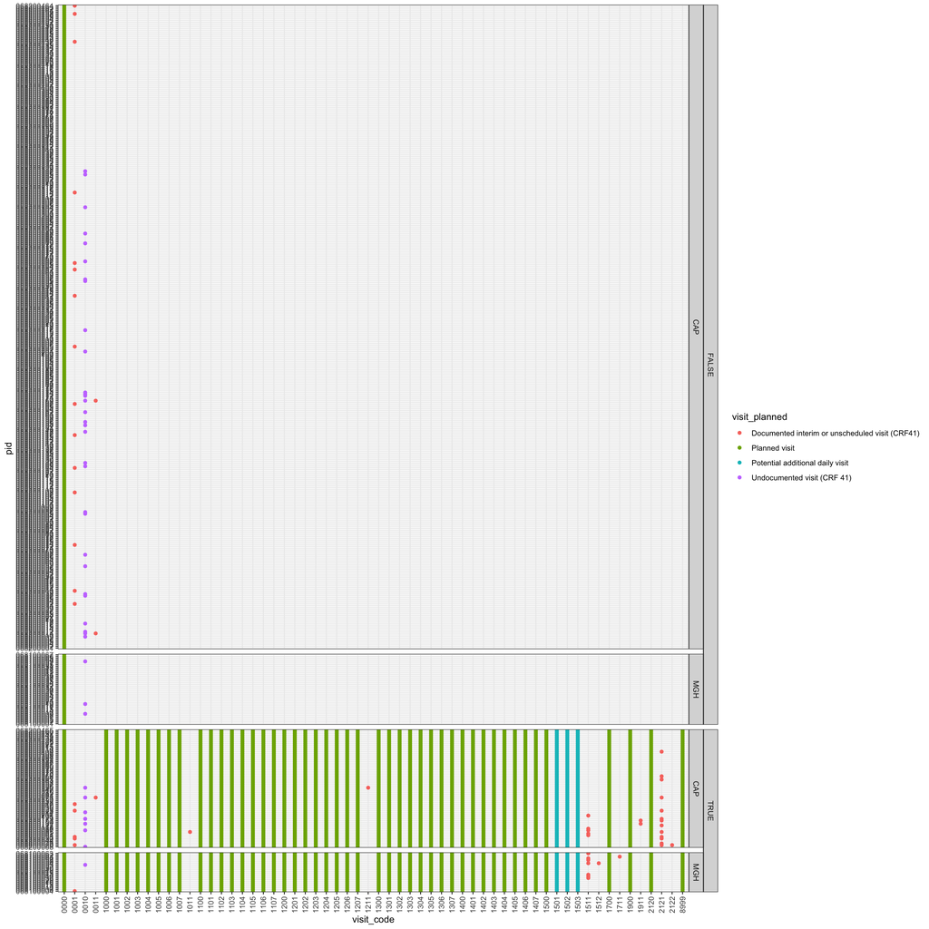

```r
visits |>
  left_join(participants) |>
  ggplot() +
  aes(x = visit_code, y = pid, col = visit_planned) +
  geom_point() +
  ggh4x::facet_nested(vars(randomized, site), scales = "free", space = "free") +
  theme(
    axis.text.x = element_text(angle = 90, vjust = 0.5)
  )
```

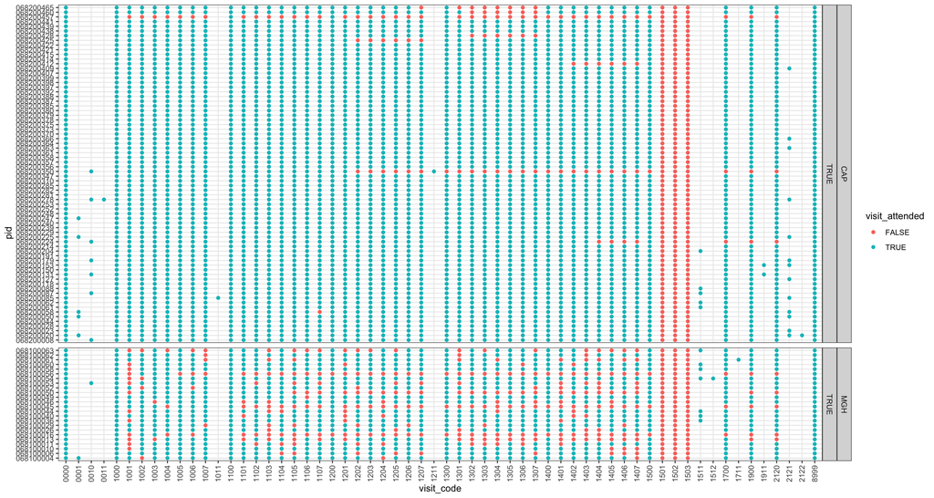

```r
visits |>
  left_join(participants) |>
  filter(randomized) |>
  ggplot() +
  aes(x = visit_code, y = pid, col = visit_attended) +
  geom_point() +
  facet_grid(site + randomized ~ ., scales = "free", space = "free") +
  theme(
    axis.text.x = element_text(angle = 90, vjust = 0.5)
  )
```

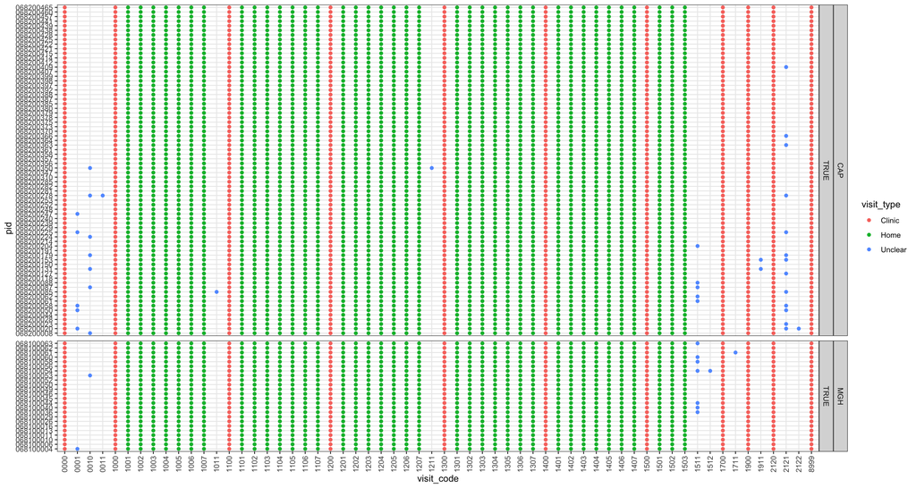

```r
visits |>
  left_join(participants) |>
  filter(randomized) |>
  ggplot() +
  aes(x = visit_code, y = pid, col = visit_type) +
  geom_point() +
  facet_grid(site + randomized ~ ., scales = "free", space = "free") +
  theme(
    axis.text.x = element_text(angle = 90, vjust = 0.5)
  )
```

```r
visits <- visits |> select(-expected)
```

### Specimen collection

#### Clinic visits (CRF35)

- `specimen_collection_swab` (number of self-collected swabs) [CRF35]
- `specimen_collection_softcup` (`collected`, `not collected`, `unclear`) [CRF35]
- `specimen_collection_cytobrush` (`collected`, `not collected`, `unclear`) [CRF35]

```r
visits <-
  visits |>
  left_join(
    crf_clean$crf35 |>
      mutate(pid = pid |> as.character()) |>
      select(
        pid,
        visit_code,
        self_collected_swabs,
        starts_with("softcup"),
        endocervical_cytobrush
      ) |>
      mutate(
        specimen_collection_swab = self_collected_swabs,
        specimen_collection_softcup = case_when(
          (softcup_time_placed == "Not done") ~ "not collected",
          (softcup == "Checked") & str_detect(softcup_time_placed, "[0-9]*:[0-0]*") ~ "collected",
          (softcup == "Checked") &
            is.na(softcup_time_placed) ~ "likely collected (duration unknown)",
          (softcup == "Unchecked") &
            str_detect(softcup_time_placed, "[0-9]*:[0-0]*") ~ "likely collected",
          (softcup == "Unchecked") & !is.na(softcup_time_placed) ~ "unclear",
          ((softcup == "Unchecked") | (softcup == "Not done")) &
            is.na(softcup_time_placed) ~ "not collected",
          TRUE ~ "???"
        ),
        specimen_collection_cytobrush = case_when(
          (endocervical_cytobrush == "Checked") ~ "collected",
          (endocervical_cytobrush == "Unchecked") ~ "not collected",
          (endocervical_cytobrush == "Not done") ~ "not collected",
          TRUE ~ "???"
        )
      ) |>
      select(pid, visit_code, starts_with("specimen")),
    by = join_by(pid, visit_code)
  )
```

```r
visits |>
  dplyr::count(
    specimen_collection_swab > 0,
    specimen_collection_softcup,
    specimen_collection_cytobrush
  ) |>
  gt()
```

| specimen_collection_swab > 0 | specimen_collection_softcup | specimen_collection_cytobrush | n |
| --- | --- | --- | --- |
| FALSE | not collected | not collected | 2 |
| TRUE | collected | collected | 365 |
| TRUE | collected | not collected | 542 |
| TRUE | likely collected | collected | 1 |
| TRUE | likely collected | not collected | 4 |
| TRUE | likely collected (duration unknown) | not collected | 1 |
| TRUE | not collected | collected | 3 |
| TRUE | not collected | not collected | 326 |
| NA | ??? | ??? | 7 |
| NA | collected | collected | 1 |
| NA | not collected | collected | 1 |
| NA | not collected | not collected | 10 |
| NA | NA | NA | 3974 |

```r
crf47_long <-
  crf_clean$crf47 |>
  select(pid, dfseq, study_day, swabs_brought, abnormal_swabs, contains("_visit_code")) |> # , contains("abnormal_swab")
  rename(crf_visit_code = dfseq) |>
  pivot_longer(
    cols = -c(pid, crf_visit_code, study_day, swabs_brought, abnormal_swabs),
    names_to = "home_swab_nb",
    values_to = "home_swab_visit_code"
  ) |>
  mutate(
    home_swab_nb = home_swab_nb |> parse_number()
  )
```

## Dictionary

```r
visits_variable_dictionary <-
  tibble(
    variable = colnames(visits)
  ) |>
  mutate(
    description = case_when(
      variable == "pid" ~ "Participant ID",
      variable == "visit_code" ~ "4-digit visit code (character)",
      variable == "study_day" ~ "Relative study day with respect to the enrollment visit (day 0)",
      variable ==
        "n_distinct_study_days" ~ "Number of distinct study day for that visit code (most often a number larger than 1 denotes a re-screening visit)",
      variable ==
        "crf_plates" ~ "CRF plates that have been filled at that visit for that participant.",
      variable ==
        "visit_attended" ~ "Whether the visit was attended by the participant. For home visit, it is whether a CRF was filled for that visit code.",
      variable == "visit_planned" ~ "Whether the visit was planned or not.",
      variable ==
        "visit_type" ~ "Type of the visit: clinic or home (or unclear for some 'unexpected' visit codes)",
      variable ==
        "specimen_collection_swab" ~ "Number of self-collected swabs at that visit (CRF35)",
      variable ==
        "specimen_collection_softcup" ~ "Whether softcup was collected at that visit (CRF35)",
      variable ==
        "specimen_collection_cytobrush" ~ "Whether endocervical cytobrush was collected at that visit (CRF35)",

      TRUE ~ "???"
    )
  )
```

```r
visits_variable_dictionary |> gt()
```

| variable | description |
| --- | --- |
| pid | Participant ID |
| visit_code | 4-digit visit code (character) |
| study_day | Relative study day with respect to the enrollment visit (day 0) |
| n_distinct_study_days | Number of distinct study day for that visit code (most often a number larger than 1 denotes a re-screening visit) |
| crf_plates | CRF plates that have been filled at that visit for that participant. |
| visit_attended | Whether the visit was attended by the participant. For home visit, it is whether a CRF was filled for that visit code. |
| visit_planned | Whether the visit was planned or not. |
| visit_type | Type of the visit: clinic or home (or unclear for some 'unexpected' visit codes) |
| specimen_collection_swab | Number of self-collected swabs at that visit (CRF35) |
| specimen_collection_softcup | Whether softcup was collected at that visit (CRF35) |
| specimen_collection_cytobrush | Whether endocervical cytobrush was collected at that visit (CRF35) |

# Population flags (`ITT`, `mITT` and `PP`)

The study population flags (ITT, mITT, PP) are built using the following steps and criteria:

- We define an eligibility flag from CRF7 (we take the last screening visit for participants who came twice);
- We create two variables related to sample collection from CRF35 data (Specimen collection)
  - `n_swabs_post_product` that counts the total number of swabs after product administration (*i.e.,* from the first follow-up visit, which is visit 1200 for all participants, including `LC106-o` participants))
  - `n_swabs_post_product_prior_week7` that counts the total number of swabs from at clinic visits 1200 to 1500 (incl.).
- We identify replaced participants from CRF44 (Replacement) to exclude participants that have been replaced from the PP;
- We determine the number of missed doses from CRF23 (Product Use) and/or our “consolidated” product exposure table to identify participants who took at least one dose of study product (mITT) or 80% of the doses (PP).
- We identify participants who take a concomitant antibiotics (ciprofloxacin, fosfomycin or metonidazole) betweenn day 7 and day 35 from CRF31 to exclude them from the PP;
- Finally, from these variables, we can define:
  - ITT:
    - all randomized participants (have a treatment code in CRF13)
  - mITT:
    - ITT &
    - met eligibility (CRF7) &
    - `n_product_doses > 0` &
    - `n_swabs_post_product > 0`
  - PP:
    - ITT &
    - not replaced (CRF44) &
    - did not meet replacement criteria (CRF33, 20, 31 and 15) &
    - `n_product_doses > 0.8 * max_product_doses` &
    - `n_swabs_post_product_prior_week7 > 0`

We first look at the eligibility from CRF7.

```r
# ELIGIBILITY

# we add information about eligibility (CRF7)
eligibility <-
  crf_clean$crf7 |>
  select(pid, dfseq, meet_eligibility) |>
  arrange(pid, dfseq) |>
  mutate(pid = pid |> as.character()) |>
  group_by(pid) |>
  summarize(
    n = n(),
    meet_eligibility = last(meet_eligibility, order_by = dfseq),
    eligibility_all = str_c(meet_eligibility |> unique(), collapse = ", ")
  )

participants <-
  participants |>
  left_join(
    eligibility |>
      select(pid, meet_eligibility) |>
      mutate(meet_eligibility = (meet_eligibility == "Yes")),
    by = join_by(pid)
  ) |>
  mutate(meet_eligibility = meet_eligibility |> replace_na(FALSE))

rm(eligibility)


participants |>
  dplyr::count(meet_eligibility, randomized) |>
  gt::gt(caption = "All eligible participants were randomized")
```

All eligible participants were randomized

| meet_eligibility | randomized | n |
| --- | --- | --- |
| FALSE | FALSE | 436 |
| TRUE | TRUE | 96 |

Then, we look at the swabs collected at in-person visits from CRF35.

```r
# COLLECTED SWABS

# We add information from CRF35 about collected swabs at in-person visits
crf35_sub <-
  crf_clean$crf35 |>
  select(pid, dfseq, self_collected_swabs) |>
  mutate(pid = pid |> as.character()) |>
  group_by(pid) |>
  # we count how many swabs were collected after the end of intervention (i.e., from visit 1200, for all intervention arms)
  mutate(
    n_swabs_post_product = sum(self_collected_swabs[dfseq >= 1200], na.rm = TRUE),
    n_swabs_post_product_prior_week7 = sum(
      self_collected_swabs[(dfseq >= 1200) & (dfseq <= 1500)],
      na.rm = TRUE
    )
  ) |>
  ungroup() |>
  select(pid, n_swabs_post_product, n_swabs_post_product_prior_week7) |>
  distinct()

participants <-
  participants |>
  select(-any_of(c("n_swabs_post_product", "n_swabs_post_product_prior_week7"))) |>
  left_join(crf35_sub, by = "pid") |>
  mutate(
    n_swabs_post_product = n_swabs_post_product |> replace_na(0),
    n_swabs_post_product_prior_week7 = n_swabs_post_product_prior_week7 |> replace_na(0)
  )
rm(crf35_sub)


participants |>
  dplyr::count(randomized, n_swabs_post_product > 0, n_swabs_post_product_prior_week7 > 0) |>
  gt()
```

| randomized | n_swabs_post_product > 0 | n_swabs_post_product_prior_week7 > 0 | n |
| --- | --- | --- | --- |
| FALSE | FALSE | FALSE | 436 |
| TRUE | FALSE | FALSE | 4 |
| TRUE | TRUE | FALSE | 1 |
| TRUE | TRUE | TRUE | 91 |

```r
participants |>
  filter(randomized, n_swabs_post_product > 0, n_swabs_post_product_prior_week7 == 0) |>
  left_join(crf_clean$crf35 |> mutate(pid = pid |> as.character()), by = join_by(pid)) |>
  gt::gt(
    caption = "Participants that had swabs collected in the extended follow-up period but not in the follow-up period."
  )
```

Participants that had swabs collected in the extended follow-up period but not in the follow-up period.

| pid | site | location | randomized | arm | meet_eligibility | n_swabs_post_product | n_swabs_post_product_prior_week7 | uid | visit_code | dfseq | vdate_fixed | study_day | Softcup time placed | Softcup time removed | specimen1_specify | Other specimen 2 specify | Softcup | Vaginal swab | Sti testing | Amsel criteria and nugent score | Number of self collected swabs | Pap smear | Cervicovaginal swab for hpv | Endocervical cytobrush | Rectal swab | Urine | Urinalysis | Poc pregnancy | Blood sample | … |
| --- | --- | --- | --- | --- | --- | --- | --- | --- | --- | --- | --- | --- | --- | --- | --- | --- | --- | --- | --- | --- | --- | --- | --- | --- | --- | --- | --- | --- | --- | --- |
| 068100050 | MGH | US | TRUE | Blinded | TRUE | 6 | 0 | 068100050_0000 | 0000 | 0 | FALSE | -6 | 12:21 | 12:45 | psa | NA | Checked | Checked | Checked | Checked | 8 | Checked | Checked | Unchecked | Checked | Checked | Unchecked | Checked | Checked | … |
| 068100050 | MGH | US | TRUE | Blinded | TRUE | 6 | 0 | 068100050_1000 | 1000 | 1000 | FALSE | 0 | 12:21 | 12:45 | psa | NA | Checked | Checked | Unchecked | Checked | 6 | Unchecked | Unchecked | Checked | Checked | Checked | Checked | Checked | Checked | … |
| 068100050 | MGH | US | TRUE | Blinded | TRUE | 6 | 0 | 068100050_1100 | 1100 | 1100 | FALSE | 7 | 12:27 | 12:50 | psa | NA | Checked | Checked | Unchecked | Checked | 8 | Unchecked | Unchecked | Checked | Checked | Checked | Checked | Checked | Checked | … |
| 068100050 | MGH | US | TRUE | Blinded | TRUE | 6 | 0 | 068100050_1700 | 1700 | 1700 | FALSE | 50 | 13:08 | 13:29 | NA | NA | Checked | Checked | Checked | Checked | 6 | Unchecked | Checked | Checked | Checked | Checked | Checked | Unchecked | Checked | … |

We then check if the participants have been replaced (CRF44) or met any of the replacement criteria (CFR33 for bleeding, CRF20/31 for antibiotics), CRF15 for HSIL pap).

```r
# REPLACEMENT
# we check if participants have been replaced

crf44_sub <-
  crf_clean$crf44 |>
  select(pid, reason_replacement) |>
  mutate(replaced = TRUE)

participants <-
  participants |>
  select(-any_of(c("replaced"))) |>
  left_join(
    crf44_sub |> select(pid, replaced) |> mutate(pid = pid |> as.character()),
    by = "pid"
  ) |>
  mutate(replaced = replaced |> replace_na(FALSE))

rm(crf44_sub)

# or if they met any of the replacement criteria
# from SAP:
# 3.6.3 Bleeding
# If a participant has 3 days of heavy bleeding (i.e. soaking a pad at least once in a day) during study product dosing, or more than 5 days in a row of heavy bleeding during follow-up, an additional participant will be added to that study arm in the remaining randomization matrix.
# 3.6.4 Antibiotics
# If a participant needs antibiotic treatment for any reason (recurrent BV, urinary tract infection, other) before the week 5 visit, an additional participant will be added to that study arm in the remaining randomization matrix.
# 3.6.5 HSIL pap
# If the Pap smear obtained at the screening visit is read as HSIL, an additional participant will be added to that study arm in the remaining randomization matrix.

# we use CRF 33 (daily diary) for bleeding

crf33_sub <-
  crf_clean$crf33 |>
  select(pid, visit_code, vaginal_bleeding) |>
  left_join(crf_clean$crf13 |> select(pid, group4), by = join_by(pid)) |>
  mutate(
    period = case_when(
      (visit_code < 1000) ~ "pre-mtz",
      (group4 == "No") & (visit_code %in% 1000:1099) ~ "mtz",
      (group4 == "Yes") & (visit_code %in% 1001:1200) ~ "product",
      (group4 == "No") & (visit_code %in% 1100:1200) ~ "product",
      (visit_code %in% 1201:1500) ~ "follow-up",
      TRUE ~ NA_character_
    )
  ) |>
  filter(period %in% c("product", "follow-up")) |>
  group_by(pid, period) |>
  summarize(
    n_heavy_bleeding = sum(vaginal_bleeding == "Yes - Heavy", na.rm = TRUE),
    n_max_consecutive_heavy_bleeding = max(
      rle(vaginal_bleeding == "Yes - Heavy")$lengths[rle(vaginal_bleeding == "Yes - Heavy")$values],
      na.rm = TRUE
    ),
    .groups = "drop"
  ) |>
  mutate(
    replacement_criteria_bleeding = case_when(
      (period == "product" & n_heavy_bleeding >= 3) ~ TRUE,
      (period == "follow-up" & n_max_consecutive_heavy_bleeding >= 5) ~ TRUE,
      TRUE ~ FALSE
    )
  ) |>
  group_by(pid) |>
  summarise(
    replacement_criteria_bleeding = any(replacement_criteria_bleeding, na.rm = TRUE),
    .groups = "drop"
  )


# 3.6.4 Antibiotics
# If a participant needs antibiotic treatment for any reason (recurrent BV, urinary tract infection, other) before the week 5 visit, an additional participant will be added to that study arm in the remaining randomization matrix.

# we use CRF 20 (follow-up questionnaire) for antibiotics
crf20_sub <-
  crf_clean$crf20 |>
  select(pid, visit_code, used_during_past_week) |>
  filter(visit_code > 1000, visit_code <= 1500) |>
  group_by(pid) |>
  summarize(
    any_antibiotics = any(str_detect(used_during_past_week, "antibiotic"))
  )

# we use CRF 31 (concomitant medications) for antibiotics, we filter participants who take ciprofloxacin, fosfomycin or metronidazole before study_day 35

crf31_sub <-
  crf_clean$crf31 |>
  select(pid, med_start_relative_date, medication) |>
  left_join(
    visits |> filter(visit_code == "1500") |> select(pid, visit_code, study_day),
    by = "pid"
  ) |>
  filter(str_detect(
    medication,
    regex(
      "METRONIDAZOLE|FLAGYL|FOSFOMYCIN|CIPROFLOXACIN|NITROFURANTOIN|CIPROBAY|MACROBID|AZITHROMYCIN|PENICILLIN|AMOXICILLIN|AUGMENTIN|CIPROFLOXACIN|CEFTRIAXONE|DOXYCYCLINE|BENZANINE",
      ignore_case = TRUE
    )
  )) |>
  filter(med_start_relative_date < study_day) |> #  med_start_relative_date > 7
  mutate(
    any_antibiotics_crf31 = TRUE
  ) |>
  select(pid, any_antibiotics_crf31)

# 3.6.5 HSIL pap
# If the Pap smear obtained at the screening visit is read as HSIL, an additional participant will be added to that study arm in the remaining randomization matrix

# we use CRF 15 (pap smear and blood) for HSIL pap
crf15_sub <-
  crf_clean$crf15 |>
  select(pid, visit_code, pap_smear_results) |>
  filter(visit_code <= 1000) |>
  group_by(pid) |>
  summarize(
    any_HSIL = any(str_detect(pap_smear_results, "HSIL"))
  )


participants <-
  participants |>
  select(-any_of(c("replacement_criteria_bleeding"))) |>
  left_join(crf33_sub, by = "pid") |>
  mutate(replacement_criteria_bleeding = replacement_criteria_bleeding |> replace_na(FALSE)) |>
  select(-any_of(c("any_antibiotics"))) |>
  left_join(crf20_sub, by = "pid") |>
  mutate(any_antibiotics = any_antibiotics |> replace_na(FALSE)) |>
  left_join(crf31_sub, by = "pid") |>
  mutate(any_antibiotics_crf31 = any_antibiotics_crf31 |> replace_na(FALSE)) |>
  select(-any_of(c("any_HSIL"))) |>
  left_join(crf15_sub, by = "pid") |>
  mutate(any_HSIL = any_HSIL |> replace_na(FALSE)) |>
  mutate(
    meets_replacement_criteria = replacement_criteria_bleeding |
      any_antibiotics |
      any_antibiotics_crf31 |
      any_HSIL
  )

participants |>
  dplyr::count(randomized, replaced, meets_replacement_criteria) |>
  gt(caption = "Replacement criteria")
```

Replacement criteria

| randomized | replaced | meets_replacement_criteria | n |
| --- | --- | --- | --- |
| FALSE | FALSE | FALSE | 433 |
| FALSE | FALSE | TRUE | 3 |
| TRUE | FALSE | FALSE | 86 |
| TRUE | FALSE | TRUE | 8 |
| TRUE | TRUE | FALSE | 2 |

We finally look at the product use from CRF23 (Product Use) and/or our “consolidated” product exposure table to identify participants who took at least one dose of study product (mITT) or 80% of the doses (PP).

```r
# PRODUCT USE
# we add information about product use

# two ways: 1 = CRF23 aggregation
crf23_sub <-
  crf_clean$crf23 |>
  select(pid, dfseq, n_missed_days) |>
  group_by(pid) |>
  summarize(
    n_missed_days = case_when(
      all(is.na(n_missed_days)) ~ NA_integer_,
      TRUE ~ sum(n_missed_days, na.rm = TRUE)
    )
  ) |>
  mutate(n_study_product_doses = 7 - n_missed_days)

# 2. exposures table
# we use exposures table to get the number of study product doses
exposures_studyproduct_summary <-
  exposures |>
  mutate(pid = pid |> as.character()) |>
  group_by(pid) |>
  summarise(
    n_study_product_doses = sum(as.numeric(daily_self_reported_adherence_sp), na.rm = TRUE),
  ) |>
  mutate(
    n_missed_days = 7 - n_study_product_doses
  )

full_join(
  crf23_sub,
  exposures_studyproduct_summary,
  by = "pid"
) |>
  filter(
    is.na(n_study_product_doses.x) |
      is.na(n_study_product_doses.y) |
      (n_study_product_doses.x != n_study_product_doses.y)
  ) |>
  left_join(
    participants |> select(pid, randomized, arm),
    by = "pid"
  ) |>
  gt(
    caption = "Disagreement between CRF23 and exposures table"
  )
```

Disagreement between CRF23 and exposures table

| pid | n_missed_days.x | n_study_product_doses.x | n_study_product_doses.y | n_missed_days.y | randomized | arm |
| --- | --- | --- | --- | --- | --- | --- |
| 068200050 | 1 | 6 | 7 | 0 | TRUE | Blinded |
| 068200281 | 1 | 6 | 7 | 0 | TRUE | Blinded |
| 068200350 | NA | NA | 0 | 7 | TRUE | Blinded |
| 068100016 | NA | NA | 0 | 7 | TRUE | Blinded |
| 068100045 | NA | NA | 0 | 7 | TRUE | Blinded |
| 068100050 | NA | NA | 4 | 3 | TRUE | Blinded |
| 068100056 | NA | NA | 0 | 7 | TRUE | Blinded |

```r
participants <-
  participants |>
  select(-any_of(c("n_study_product_doses_crf23", "n_study_product_doses_exposures"))) |>
  left_join(
    crf23_sub |>
      mutate(n_study_product_doses_crf23 = n_study_product_doses) |>
      select(pid, n_study_product_doses_crf23),
    by = "pid"
  ) |>
  left_join(
    exposures_studyproduct_summary |>
      mutate(n_study_product_doses_exposures = pmin(7, n_study_product_doses)) |>
      select(pid, n_study_product_doses_exposures),
    by = "pid"
  ) |>
  mutate(
    n_study_product_doses_crf23 = n_study_product_doses_crf23 |> replace_na(0),
    n_study_product_doses_exposures = n_study_product_doses_exposures |> replace_na(0)
  )

participants |>
  dplyr::count(
    randomized,
    arm,
    n_study_product_doses_crf23 > 1,
    n_study_product_doses_exposures > 1
  ) |>
  gt(caption = "Number of participants with more than 1 dose according to CRF23 or exposures table")
```

Number of participants with more than 1 dose according to CRF23 or exposures table

| randomized | arm | n_study_product_doses_crf23 > 1 | n_study_product_doses_exposures > 1 | n |
| --- | --- | --- | --- | --- |
| FALSE | NA | FALSE | FALSE | 436 |
| TRUE | LC106-o | FALSE | FALSE | 1 |
| TRUE | LC106-o | TRUE | TRUE | 15 |
| TRUE | Blinded | FALSE | FALSE | 5 |
| TRUE | Blinded | FALSE | TRUE | 1 |
| TRUE | Blinded | TRUE | TRUE | 74 |

```r
participants |>
  dplyr::count(
    randomized,
    arm,
    n_study_product_doses_crf23 > 5,
    n_study_product_doses_exposures > 5
  ) |>
  gt(
    caption = "Number of participants with more than 5 doses according to CRF23 or exposures table"
  )
```

Number of participants with more than 5 doses according to CRF23 or exposures table

| randomized | arm | n_study_product_doses_crf23 > 5 | n_study_product_doses_exposures > 5 | n |
| --- | --- | --- | --- | --- |
| FALSE | NA | FALSE | FALSE | 436 |
| TRUE | LC106-o | FALSE | FALSE | 2 |
| TRUE | LC106-o | TRUE | TRUE | 14 |
| TRUE | Blinded | FALSE | FALSE | 6 |
| TRUE | Blinded | TRUE | TRUE | 74 |

We create the population flags.

```r
# create the flag
participants <-
  participants |>
  mutate(
    ITT = randomized,
    mITT = ITT & meet_eligibility & (n_study_product_doses_crf23 > 0) & (n_swabs_post_product > 0),
    PP = ITT &
      !replaced &
      !meets_replacement_criteria &
      (n_study_product_doses_crf23 > 0.8 * 7) &
      (n_swabs_post_product_prior_week7 > 0)
  )
```

```r
participants |>
  dplyr::count(randomized, ITT, mITT, PP) |>
  gt()
```

| randomized | ITT | mITT | PP | n |
| --- | --- | --- | --- | --- |
| FALSE | FALSE | FALSE | FALSE | 436 |
| TRUE | TRUE | FALSE | FALSE | 6 |
| TRUE | TRUE | TRUE | FALSE | 10 |
| TRUE | TRUE | TRUE | TRUE | 80 |

```r
participants <-
  participants |>
  select(pid, site, location, randomized, arm, ITT, mITT, PP, everything())
```

## Dictionary

```r
participants_variable_dictionary <-
  tibble(
    variable = colnames(participants)
  ) |>
  mutate(
    description = case_when(
      variable == "pid" ~ "Participant ID",
      variable == "site" ~ "Study site (MGH or CAP)",
      variable == "location" ~ "Location of the participant (US or SA)",
      variable == "randomized" ~ "Randomized participant (TRUE or FALSE)",
      variable == "arm" ~ "Randomization arm",
      variable == "ITT" ~ "Intention-to-treat population flag (TRUE or FALSE)",
      variable == "mITT" ~ "Modified intention-to-treat population flag (TRUE or FALSE)",
      variable == "PP" ~ "Per-protocol population flag (TRUE or FALSE)",
      variable ==
        "meet_eligibility" ~ "Eligibility flag (TRUE or FALSE): whether participant met eligibility criteria at their last screening visit",
      variable == "n_swabs_post_product" ~ "Number of swabs collected from visit 1200 (incl.)",
      variable ==
        "n_swabs_post_product_prior_week7" ~ "Number of swabs collected from visit 1200 to 1500 (incl.)",
      variable == "replaced" ~ "Replacement flag (TRUE or FALSE): whether participant was replaced",
      variable ==
        "replacement_criteria_bleeding" ~ "Whether participant met replacement criteria related to bleeding.",
      variable == "any_antibiotics" ~ "Whether participant used any antibiotics before visit 1500.",
      variable ==
        "any_antibiotics_crf31" ~ "Whether participant used any antibiotics before visit 1500 according to CRF31 (concomitant medications).",
      variable == "any_HSIL" ~ "Whether participant had HSIL pap at screening visit.",
      variable ==
        "meets_replacement_criteria" ~ "Whether participant meets any of the replacement criteria (bleeding, antibiotics, HSIL pap)",
      variable ==
        "n_study_product_doses_crf23" ~ "Number of doses taken (as reported in CRF23; missing values imputed to 0)",
      variable ==
        "n_study_product_doses_exposures" ~ "Number of doses taken (as reported in exposures table)",

      TRUE ~ "???"
    )
  )
```

```r
participants_variable_dictionary |> gt()
```

| variable | description |
| --- | --- |
| pid | Participant ID |
| site | Study site (MGH or CAP) |
| location | Location of the participant (US or SA) |
| randomized | Randomized participant (TRUE or FALSE) |
| arm | Randomization arm |
| ITT | Intention-to-treat population flag (TRUE or FALSE) |
| mITT | Modified intention-to-treat population flag (TRUE or FALSE) |
| PP | Per-protocol population flag (TRUE or FALSE) |
| meet_eligibility | Eligibility flag (TRUE or FALSE): whether participant met eligibility criteria at their last screening visit |
| n_swabs_post_product | Number of swabs collected from visit 1200 (incl.) |
| n_swabs_post_product_prior_week7 | Number of swabs collected from visit 1200 to 1500 (incl.) |
| replaced | Replacement flag (TRUE or FALSE): whether participant was replaced |
| replacement_criteria_bleeding | Whether participant met replacement criteria related to bleeding. |
| any_antibiotics | Whether participant used any antibiotics before visit 1500. |
| any_antibiotics_crf31 | Whether participant used any antibiotics before visit 1500 according to CRF31 (concomitant medications). |
| any_HSIL | Whether participant had HSIL pap at screening visit. |
| meets_replacement_criteria | Whether participant meets any of the replacement criteria (bleeding, antibiotics, HSIL pap) |
| n_study_product_doses_crf23 | Number of doses taken (as reported in CRF23; missing values imputed to 0) |
| n_study_product_doses_exposures | Number of doses taken (as reported in exposures table) |

# Exports

```r
dir <- get_01_output_dir()

save(
  participants,
  file = str_c(dir, "01_participants_", today() |> str_replace_all("-", ""), ".Rdata")
)
save(
  participants_variable_dictionary,
  file = str_c(
    dir,
    "01_participants_variable_dictionary_",
    today() |> str_replace_all("-", ""),
    ".Rdata"
  )
)
save(
  visits_long,
  file = str_c(dir, "01_visits_long_", today() |> str_replace_all("-", ""), ".Rdata")
)
save(visits, file = str_c(dir, "01_visits_", today() |> str_replace_all("-", ""), ".Rdata"))
save(
  visits_variable_dictionary,
  file = str_c(dir, "01_visits_variable_dictionary_", today() |> str_replace_all("-", ""), ".RData")
)
```